# **Supplemental Materials** for “Statements issued by academic medical institutions after George Floyd’s killing by police and subsequent unrest in the United States: cross-sectional study”

Mathew V Kiang and Alexander C Tsai

```r
library(tidyverse)
library(here)
library(DT)
library(knitr)
```

```r
## Read in processed data
analytic_df <- readRDS(here("data_private", "social_mission_analytic_df.RDS"))
word_df <- readRDS(here("data_private", "social_mission_tokenized_words.RDS"))
sentence_df <- readRDS(here("data_private", "social_mission_tokenized_sentences.RDS"))
ngram2_df <- readRDS(here("data_private", "social_mission_tokenized_bigrams.RDS"))
ngram3_df <- readRDS(here("data_private", "social_mission_tokenized_trigrams.RDS"))
summary_df <- readRDS(here("data_private", "social_mission_keyword_summary_df.RDS"))
```

## List institutions included in the data set

A total of 19 statements are included in the data set. The institutions, listed in alphabetical order, are:

```r
analytic_df %>%
  arrange(institution) %>%
  transmute(institution,
            institution_star =
              paste0(
                institution,
                ifelse(public == 0, "*", ""),
                ifelse(!grepl("[Dd]{1}ean", position), "^", "")
              ),
            mullan_rank,
            nih_rank,
            usnwr_rank) %>%
  select(-institution_star) %>%
  knitr::kable(
    format = "html",
    digits = 0,
    col.names = c("Institution", "Social Mission Rank (Mullan)", "NIH Funding Rank (2018)", "USN&WR Rank (2021)")
  )
```

| Institution | Social Mission Rank (Mullan) | NIH Funding Rank (2018) | USN&WR Rank (2021) |
| --- | --- | --- | --- |
| East Carolina University Brody School of Medicine | 7 | NA | NA |
| East Tennessee State University Quillen College of Medicine | 12 | NA | NA |
| Howard University | 3 | NA | NA |
| Marshall University Joan C. Edwards University | 16 | NA | NA |
| Meharry Medical College | 2 | NA | NA |
| Michigan State University College of Human Medicine | 6 | NA | NA |
| Morehouse School of Medicine | 1 | NA | NA |
| Oregon Health and Science University | 11 | 25 | 28 |
| Southern Illinois University | 15 | NA | NA |
| University of Illinois | 18 | NA | NA |
| University of Iowa (Carver) | 10 | 41 | 34 |
| University of Kansas | 5 | NA | NA |
| University of Kentucky | 14 | 47 | 68 |
| University of Massachusetts Worcester | 17 | 34 | 47 |
| University of Mississippi | 13 | NA | NA |
| University of New Mexico | 19 | NA | NA |
| University of South Alabama | 8 | NA | NA |
| University of Wisconsin Madison | 20 | 24 | 27 |
| Wright State University Boonshoft School of Medicine | 4 | NA | NA |

## Dates of statements

All statements occurred between 2020-01-20 and 2020-11-20 with 6 undated statements.

```r
analytic_df %>%
  count(date)
```

```
## # A tibble: 7 x 2
##   date           n
##   <date>     <int>
## 1 2020-01-20     4
## 2 2020-02-20     3
## 3 2020-03-20     3
## 4 2020-04-20     1
## 5 2020-08-20     1
## 6 2020-11-20     1
## 7 NA             6
```

The median and IQR of dates is:

```r
sort(analytic_df$date)[c(round(.5 * NROW(analytic_df)),
                         round(.25 * NROW(analytic_df)),
                         round(.75 * NROW(analytic_df)))]
```

```
## [1] "2020-03-20" "2020-02-20" NA
```

## Descriptive statistics of statements

### Total number of unique words (excluding stop words)

```r
word_df %>%
  filter(keep_word) %>%
  pull(word) %>%
  n_distinct()
```

```
## [1] 1860
```

### Total number of words (including repeats, excluding stop words)

```r
word_df %>%
  filter(keep_word) %>%
  NROW()
```

```
## [1] 4078
```

### Total number of sentences

```r
sentence_df %>%
  NROW()
```

```
## [1] 489
```

Note that counting sentences is a rough approximation because things like “Mr.” will count as their own sentence.

### Words by institution (including repeats and stop words)

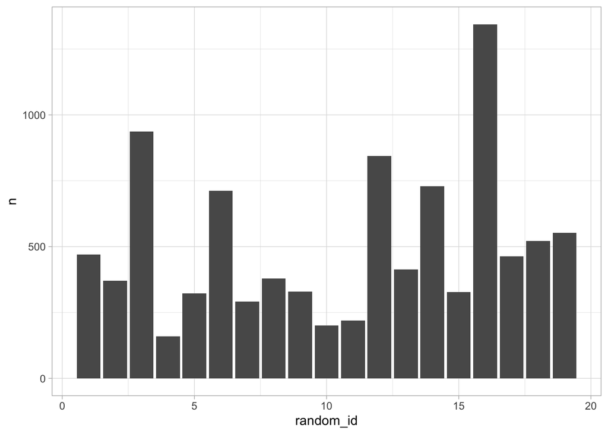

```r
x <- word_df %>%
    count(random_id, sort = TRUE)

ggplot(x, aes(x = random_id, y = n)) +
    geom_col() +
    theme_light()
```

```r
summary(x$n)
```

```
##    Min. 1st Qu.  Median    Mean 3rd Qu.    Max.
##   159.0   325.0   413.0   504.5   632.0  1344.0
```

### Words by institution (including repeats, excluding stop words)

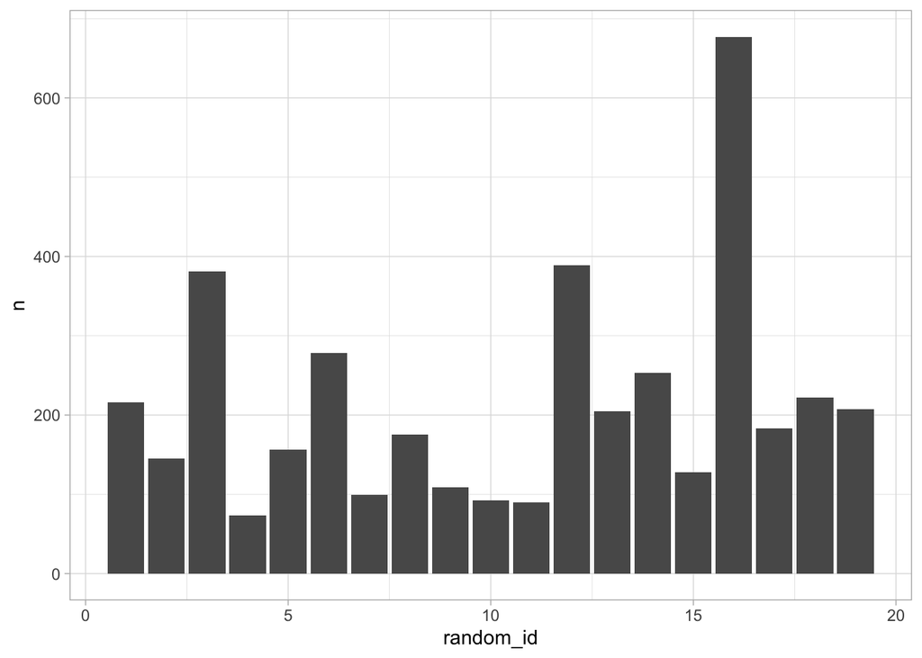

```r
x <- word_df %>%
    filter(keep_word) %>%
    count(random_id, sort = TRUE)

ggplot(x, aes(x = random_id, y = n)) +
    geom_col() +
    theme_light()
```

```r
summary(x$n)
```

```
##    Min. 1st Qu.  Median    Mean 3rd Qu.    Max.
##    73.0   118.5   183.0   214.6   237.5   677.0
```

## Most common words and n-grams

### 100 most common words and word stems

Here, we tabulate the frequency of each `word_stem` and `word`. The `n_word_stem` and `n_word` columns show the frequency of stems and words, respectively. The `n_inst_*` columns show the number of unique institutes that used each word. Sorting by `n_inst_word` will result in the words that were used by the highest number of different institutions.

```r
x <- word_df %>%
    filter(keep_word) %>%
    group_by(word_stem) %>%
    mutate(n_word_stem = n(),
           n_inst_word_stem = n_distinct(random_id)) %>%
    group_by(word) %>%
    mutate(n_word = n(), n_inst_word = n_distinct(random_id)) %>%
    select(word_stem,
           word,
           n_word_stem,
           n_inst_word_stem,
           n_word,
           n_inst_word) %>%
    distinct() %>%
    ungroup() %>%
    mutate(stem_rank = min_rank(desc(n_word_stem))) %>%
    filter(stem_rank <= 100) %>%
    arrange(desc(n_word_stem))

x %>%
    datatable(rownames = FALSE)
```

| word_stem | word | n_word_stem | n_inst_word_stem | n_word | n_inst_word | stem_rank |
| --- | --- | --- | --- | --- | --- | --- |
| commun | communities | 60 | 17 | 20 | 12 | 1 |
| commun | community | 60 | 17 | 40 | 16 | 1 |
| racism | racism | 52 | 15 | 52 | 15 | 3 |
| health | health | 45 | 12 | 45 | 12 | 4 |
| divers | diversity | 37 | 9 | 32 | 9 | 5 |
| divers | diverse | 37 | 9 | 5 | 4 | 5 |
| live | live | 28 | 13 | 7 | 6 | 7 |
| live | lives | 28 | 13 | 19 | 11 | 7 |
| peopl | people | 28 | 10 | 28 | 10 | 7 |
| live | living | 28 | 13 | 1 | 1 | 7 |

[output cut: 93 more lines]

### 100 most common 2-gram phases

Below, we show the top 100 most commonly used 2-gram phrases in both the stemmed and unstemmed format. Similar to above, we show the counts (`n_ngram_stem` for the stemmed version and `n_ngram` for the unstemmed version) as well as the number of unique institutions that used the phrase (e.g., `n_inst_ngram_stem` for the stemmed version).

```r
x <- ngram2_df %>%
    group_by(ngram2_stem) %>%
    mutate(n_ngram_stem = n(),
           n_inst_ngram_stem = n_distinct(random_id)) %>%
    group_by(ngram2) %>%
    mutate(n_ngram = n(),
           n_inst_ngram = n_distinct(random_id)) %>%
    select(ngram2_stem,
           ngram2,
           n_ngram_stem,
           n_inst_ngram_stem,
           n_ngram,
           n_inst_ngram) %>%
    distinct() %>%
    ungroup() %>%
    mutate(stem_rank = min_rank(desc(n_ngram_stem))) %>%
    filter(stem_rank <= 100) %>%
    arrange(desc(n_ngram_stem))

x %>%
    datatable(rownames = FALSE)
```

| ngram2_stem | ngram2 | n_ngram_stem | n_inst_ngram_stem | n_ngram | n_inst_ngram | stem_rank |
| --- | --- | --- | --- | --- | --- | --- |
| georg floyd | george floyd | 19 | 14 | 19 | 14 | 1 |
| african american | african americans | 17 | 6 | 11 | 4 | 2 |
| african american | african american | 17 | 6 | 6 | 3 | 2 |
| health care | health care | 11 | 7 | 11 | 7 | 4 |
| medic school | medical school | 7 | 4 | 6 | 4 | 5 |
| medic school | medical schools | 7 | 4 | 1 | 1 | 5 |
| ahmaud arberi | ahmaud arbery | 7 | 6 | 7 | 6 | 5 |
| breonna taylor | breonna taylor | 7 | 6 | 7 | 6 | 5 |
| anti racism | anti racism | 6 | 4 | 6 | 4 | 9 |
| public health | public health | 5 | 3 | 5 | 3 | 10 |

[output cut: 109 more lines]

### Most common 3-gram phrases

Like above but for three word phrases

```r
x <- ngram3_df %>%
    group_by(ngram3_stem) %>%
    mutate(n_ngram_stem = n(),
           n_inst_ngram_stem = n_distinct(random_id)) %>%
    group_by(ngram3) %>%
    mutate(n_ngram = n(),
           n_inst_ngram = n_distinct(random_id)) %>%
    select(ngram3_stem,
           ngram3,
           n_ngram_stem,
           n_inst_ngram_stem,
           n_ngram,
           n_inst_ngram) %>%
    distinct() %>%
    ungroup() %>%
    filter(n_ngram_stem > 1) %>%
    arrange(desc(n_ngram_stem))

x %>%
    datatable(rownames = FALSE)
```

| ngram3_stem | ngram3 | n_ngram_stem | n_inst_ngram_stem | n_ngram | n_inst_ngram |
| --- | --- | --- | --- | --- | --- |
| anti racist organ | anti racist organization | 3 | 1 | 3 | 1 |
| m.d hood ceremoni | m.d hooding ceremony | 2 | 1 | 2 | 1 |
| minneapoli polic offic | minneapolis police officers | 2 | 2 | 1 | 1 |
| health care racial | health care racial | 2 | 2 | 2 | 2 |
| unconsci bia train | unconscious bias training | 2 | 1 | 2 | 1 |
| umass medic school | umass medical school | 2 | 1 | 2 | 1 |
| student faculti staff | students faculty staff | 2 | 2 | 1 | 1 |
| civil right movement | civil rights movement | 2 | 2 | 2 | 2 |
| black african american | black african american | 2 | 1 | 2 | 1 |
| african american commun | african american community | 2 | 2 | 2 | 2 |

[output cut: 5 more lines]